# What shoes to you wear?

```css
body { background-color: lightblue ;
color: #756bb1
}
```

## Plot 1

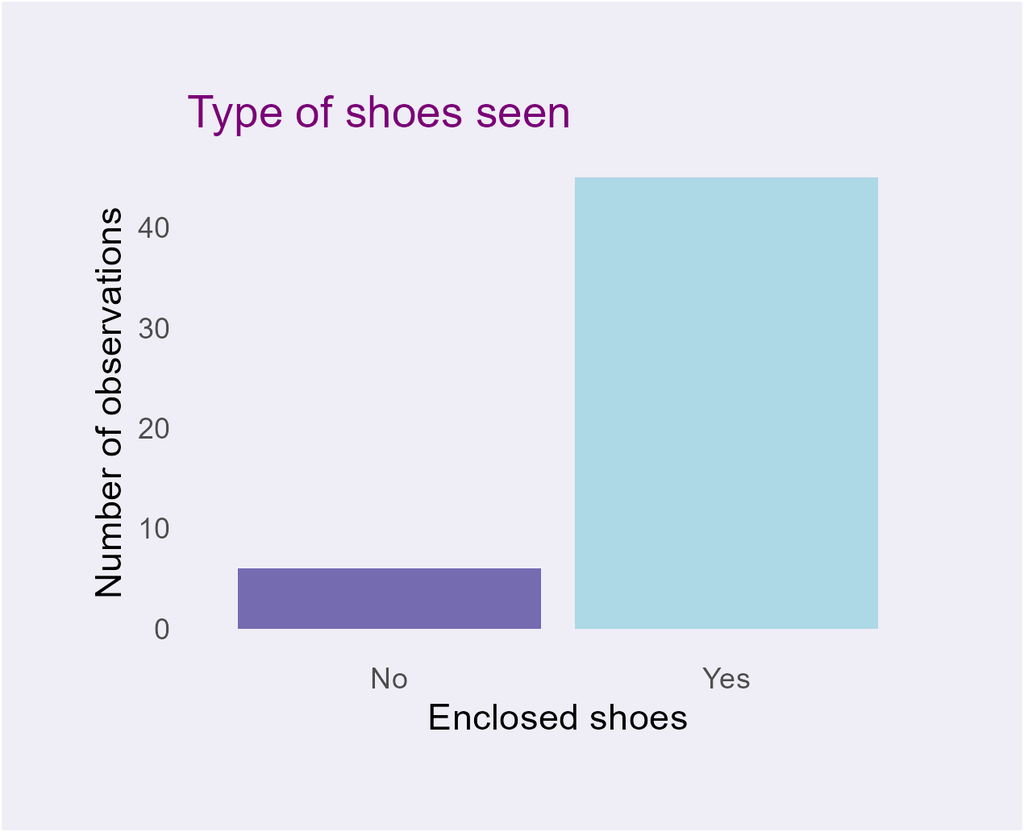

Full closed shoes vs open shoes

In this first plot it is looking at the amount of shoes that are enclosed or not. This was done by observing if the shoes were fully covered or not. When doing this I did expect to see more enclosed shoes as it is more common which the graph shows. Taking my second set of data, I did seem to notice that there were fewer open shoes, such as sandals and flip flops, I think this was because there was colder wetter weather as we more further away from summer. Looking at the data the number of observations of enclosed shoes is much high than the observations for non enclosed shoes.